# Question 4: Are there differences in activity patterns between weekdays and weekends?

## Question 4: Are there differences in activity patterns between weekdays and weekends?

For this part the **weekdays()** function may be of some help here. Use the dataset with the filled-in missing values for this part.

1) Create a new factor variable in the dataset with two levels – “weekday” and “weekend” indicating whether a given date is a weekday or weekend day.

I used the **ifelse()** function in order to test if each date in the dataset is either a weekend day or weekday day:

```r
fixed_data$wday <- ifelse(weekdays(as.Date(fixed_data$date)) %in% c("Saturday","Sunday"),"weekend","weekday")
fixed_data$wday <- as.factor(fixed_data$wday)
summary(fixed_data)
```

```
##      steps                date          interval           wday
##  Min.   :  0.00   2012-10-01:  288   Min.   :   0.0   weekday:12960
##  1st Qu.:  0.00   2012-10-02:  288   1st Qu.: 588.8   weekend: 4608
##  Median :  0.00   2012-10-03:  288   Median :1177.5
##  Mean   : 37.38   2012-10-04:  288   Mean   :1177.5
##  3rd Qu.: 27.00   2012-10-05:  288   3rd Qu.:1766.2
##  Max.   :806.00   2012-10-06:  288   Max.   :2355.0
##                   (Other)   :15840
```

2) Make a panel plot containing a time series plot (i.e. type = “l”) of the 5-minute interval (x-axis) and the average number of steps taken, averaged across all weekday days or weekend days (y-axis). See the README file in the GitHub repository to see an example of what this plot should look like using simulated data.

```r
require(dplyr)
require(ggplot2)

steps_mean_weekday <- tapply(fixed_data[fixed_data$wday=="weekday",]$steps,fixed_data[fixed_data$wday=="weekday",]$interval,mean)

steps_mean_weekend <- tapply(fixed_data[fixed_data$wday=="weekend",]$steps,fixed_data[fixed_data$wday=="weekend",]$interval,mean)

steps_mean_weekday <- as.data.frame(steps_mean_weekday)
steps_mean_weekday$wday <- "weekday"
steps_mean_weekday$interval <- c(1:288)
steps_mean_weekday <- select(steps_mean_weekday,interval, mean_steps_per_interval=steps_mean_weekday,wday)
head(steps_mean_weekday)
```

```
##    interval mean_steps_per_interval    wday
## 0         1              2.25115304 weekday
## 5         2              0.44528302 weekday
## 10        3              0.17316562 weekday
## 15        4              0.19790356 weekday
## 20        5              0.09895178 weekday
## 25        6              1.59035639 weekday
```

```r
steps_mean_weekend <- as.data.frame(steps_mean_weekend)
steps_mean_weekend$wday <- "weekend"
steps_mean_weekend$interval <- c(1:288)
steps_mean_weekend <- select(steps_mean_weekend,interval, mean_steps_per_interval=steps_mean_weekend,wday)
head(steps_mean_weekend)
```

```
##    interval mean_steps_per_interval    wday
## 0         1             0.214622642 weekend
## 5         2             0.042452830 weekend
## 10        3             0.016509434 weekend
## 15        4             0.018867925 weekend
## 20        5             0.009433962 weekend
## 25        6             3.511792453 weekend
```

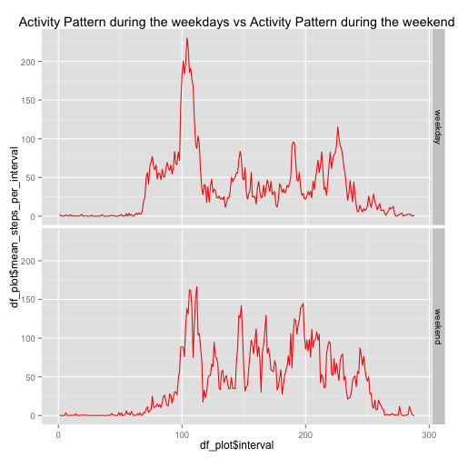

```r
df_plot <- rbind(steps_mean_weekday,steps_mean_weekend)
p <- ggplot(df_plot,aes(df_plot$interval,df_plot$mean_steps_per_interval)) + geom_line(col="red") + facet_grid(wday ~ .) + ggtitle("Activity Pattern during the weekdays vs Activity Pattern during the weekend")
print(p)
```